# Analysis of registered covid-19 cases and numbers of death

Fanni Kiss

2020 11 29

## Introduction

Current report aims to analyse the pattern of association between registered COVID-19 cases per capita and registered numbers of death per capita due to COVID-19 on 22 September 2020. GitHub https://github.com/fanni-k/DA2.

## Choosing a model

As the dependent variable and the explanatory variable both skewed with long right tale and does not contain negative numbers, the log transformation could be applied on the values. We compared four different models: * level-level model * log-level model * level-log model * log-log model

On the plots, we can observe that the log-log model makes the association close to linear between the both variable. This model shows us, that how many percent higher number of death per capita associated with 1% higher number of cases per capita by country, which is a meaningful interpretation. Furhtermore, both of the variables are skewed with a long right tale, so the log transformation balance the distribution for the further analysis. So, the log-log regression is going to be analysed in the further analysis.

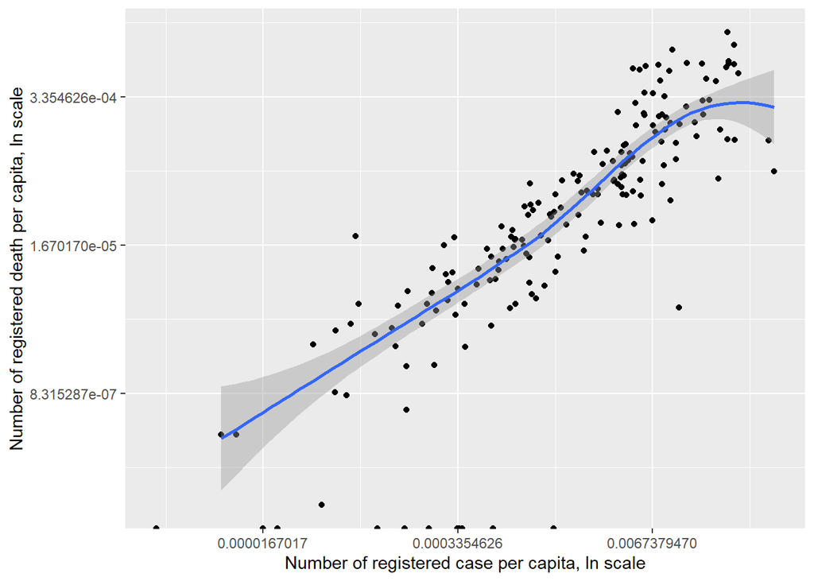

## Regression

In the analysis, we make five regression:

- Simple linear regression (log-log):
  - reg1: ln_death_per_capita = alpha + beta * ln_case_per_capita
- Quadratic linear regression:
  - reg2: ln_death_per_capita = alpha + beta_1 * ln_case_per_capita + beta_2 * ln_case_per_capita^2
- Cubic liear regression:
  - reg3: ln_death_per_capita = alpha + beta_1 * ln_case_per_capita + beta_2 * ln_case_per_capita^2 + beta_3 * ln_case_per_capita^3
- Piecewise linear spline regression
  - reg4: ln_death_per_capita = alpha + beta_1 * ln_case_per_capita * 1(case_per_capita < 0.00091) + beta_2 * ln_case_per_capita * 1(case_per_capita >= 0.00091)
- Weighted linear regression, using population as weights
  - reg5: ln_death_per_capita = alpha + beta * ln_case_per_capita, weights: population

For the further analysis, we pick the most reliable model. Based on the adjusted R-squared, it is the weighted linear regression model, which uses population as weights. In this case, the R-squared is 0.89, which could be accepted as a relatively high R-squared value.

The result of the weighted linear regression model is ln_death_per_capita = -4.25 + 0.91 * ln_case_per_capita, which means that the number of death is 0.91% higher on average for observations with one percent higher number of cases due to COVID.

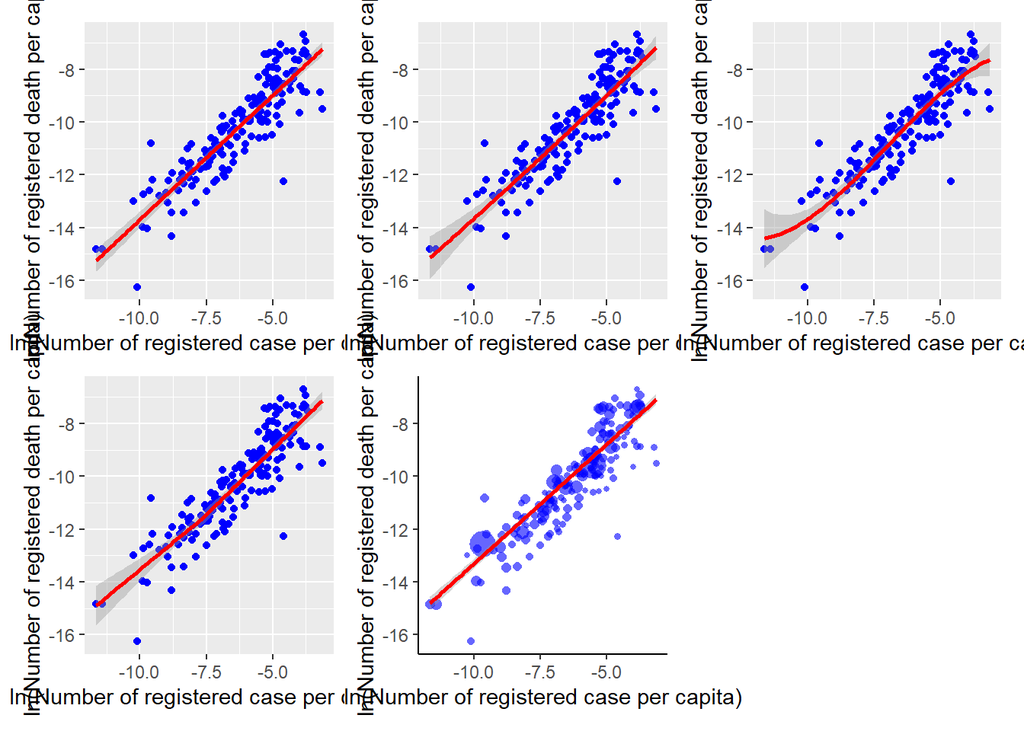

## Hypothesis testing

In the hypothesis testing, we test if there is a significant linear relationship between the number of death and number of cases on a 0.05 level of significance.

- H0: beta = 0, or the slope of the regression line is zero
- H1: beat != 0, or the slope of the regression line is not equal to zero. If the relationship between the death and cases is significant, the slope will not equal to zero.

The p-value of the model is 2.2e-16, which is less than the significance level (0.05), we cannot accept the null hypothesis.

```
## Linear hypothesis test
##
## Hypothesis:
## ln_case_per_capita = 0
##
## Model 1: restricted model
## Model 2: ln_death_per_capita ~ ln_case_per_capita
##
##   Res.Df Df Chisq Pr(>Chisq)
## 1    169
## 2    168  1 119.5  < 2.2e-16 ***
## ---
## Signif. codes:  0 '***' 0.001 '**' 0.01 '*' 0.05 '.' 0.1 ' ' 1
```

## Residual analysis

Based on the residual analysis, we can observe, which countries lost and save relatively the most people. The residual analysis shows, which observations are the farest from the predicted value. Countries, where there are less death due to COVID-19 compared to the number of cases, are shown Table 1. While those countries, where there are more death due to COVID-19 compared to the number of cases, are shown Table 2.

The TOP5 countries, who saved relatively the most people

| country | ln_death_per_capita | reg5_y_pred | reg5_res |
| --- | --- | --- | --- |
| Burundi | -16.260513 | -13.403346 | -2.857167 |
| Maldives | -9.656068 | -7.867324 | -1.788744 |
| Qatar | -9.504659 | -7.086783 | -2.417876 |
| Singapore | -12.260766 | -8.415050 | -3.845716 |
| Sri Lanka | -14.332609 | -12.218580 | -2.114028 |

| country | ln_death_per_capita | reg5_y_pred | reg5_res |
| --- | --- | --- | --- |
| Belgium | -7.050640 | -8.503632 | 1.452992 |
| Italy | -7.430830 | -9.054322 | 1.623493 |
| Mexico | -7.447707 | -8.961540 | 1.513833 |
| United Kingdom | -7.373471 | -8.875977 | 1.502506 |
| Yemen | -10.815055 | -12.926908 | 2.111853 |

# Appendix

Descriptive statistics of the variables

|  | country | confirmed | death | recovered | active | country_code | population | death_per_capita | case_per_capita | ln_death_per_capita | ln_case_per_capita | ln_case_per_capita_sq | ln_case_per_capita_cb | reg5_y_pred | reg5_res |
| --- | --- | --- | --- | --- | --- | --- | --- | --- | --- | --- | --- | --- | --- | --- | --- |
|  | Length:170 | Min. : 32 | Min. : 1 | Min. : 0 | Min. : 0 | Length:170 | Min. :3.386e+04 | Min. :8.670e-08 | Min. :8.780e-06 | Min. :-16.261 | Min. :-11.644 | Min. : 9.792 | Min. :-1578.56 | Min. :-14.803 | Min. :-3.8457 |
|  | Class :character | 1st Qu.: 3864 | 1st Qu.: 64 | 1st Qu.: 1952 | 1st Qu.: 535 | Class :character | 1st Qu.:3.044e+06 | 1st Qu.:1.035e-05 | 1st Qu.:6.614e-04 | 1st Qu.:-11.479 | 1st Qu.: -7.321 | 1st Qu.: 24.938 | 1st Qu.: -392.42 | 1st Qu.:-10.886 | 1st Qu.:-0.6789 |
|  | Mode :character | Median : 15532 | Median : 284 | Median : 9672 | Median : 2619 | Mode :character | Median :1.028e+07 | Median :4.622e-05 | Median :2.579e-03 | Median : -9.982 | Median : -5.961 | Median : 35.540 | Median : -211.89 | Median : -9.653 | Median :-0.1888 |
|  | NA | Mean : 185830 | Mean : 5708 | Mean : 127664 | Mean : 29004 | NA | Mean :4.452e+07 | Mean :1.312e-04 | Mean :5.251e-03 | Mean :-10.191 | Mean : -6.272 | Mean : 42.261 | Mean : -304.89 | Mean : -9.935 | Mean :-0.2561 |
|  | NA | 3rd Qu.: 85010 | 3rd Qu.: 1696 | 3rd Qu.: 58969 | 3rd Qu.: 13492 | NA | 3rd Qu.:3.237e+07 | 3rd Qu.:1.394e-04 | 3rd Qu.:6.780e-03 | 3rd Qu.: -8.878 | 3rd Qu.: -4.994 | 3rd Qu.: 53.600 | 3rd Qu.: -124.54 | 3rd Qu.: -8.777 | 3rd Qu.: 0.2576 |
|  | NA | Max. :6902414 | Max. :200974 | Max. :4587613 | Max. :968377 | NA | Max. :1.398e+09 | Max. :1.240e-03 | Max. :4.375e-02 | Max. : -6.692 | Max. : -3.129 | Max. :135.573 | Max. : -30.64 | Max. : -7.087 | Max. : 2.1119 |
|  | NA | NA | NA | NA | NA’s :3 | NA | NA | NA | NA | NA | NA | NA | NA | NA | NA |

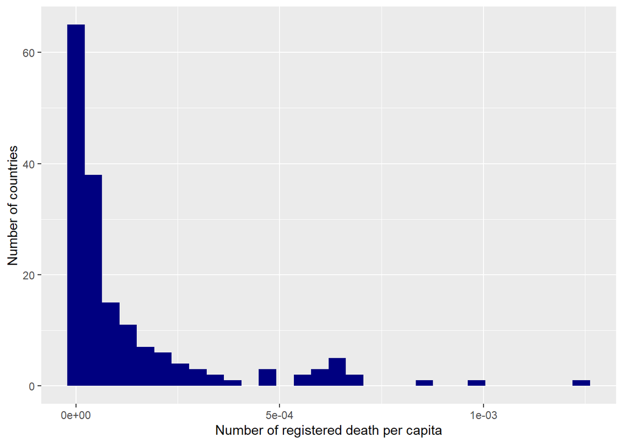

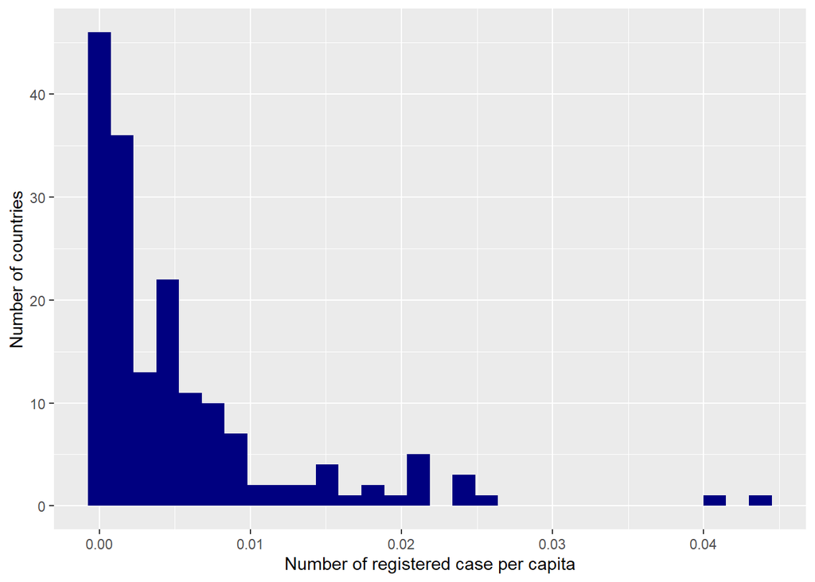

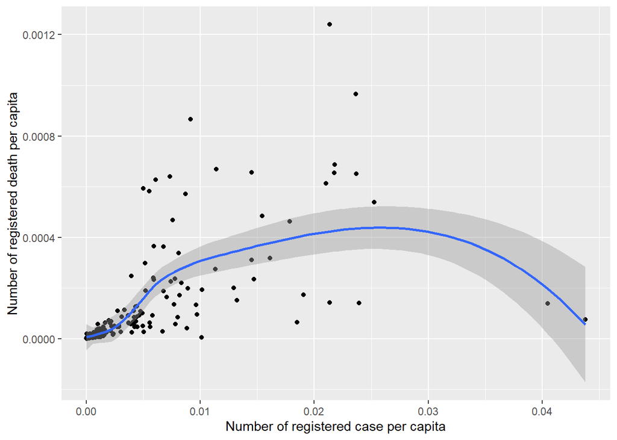

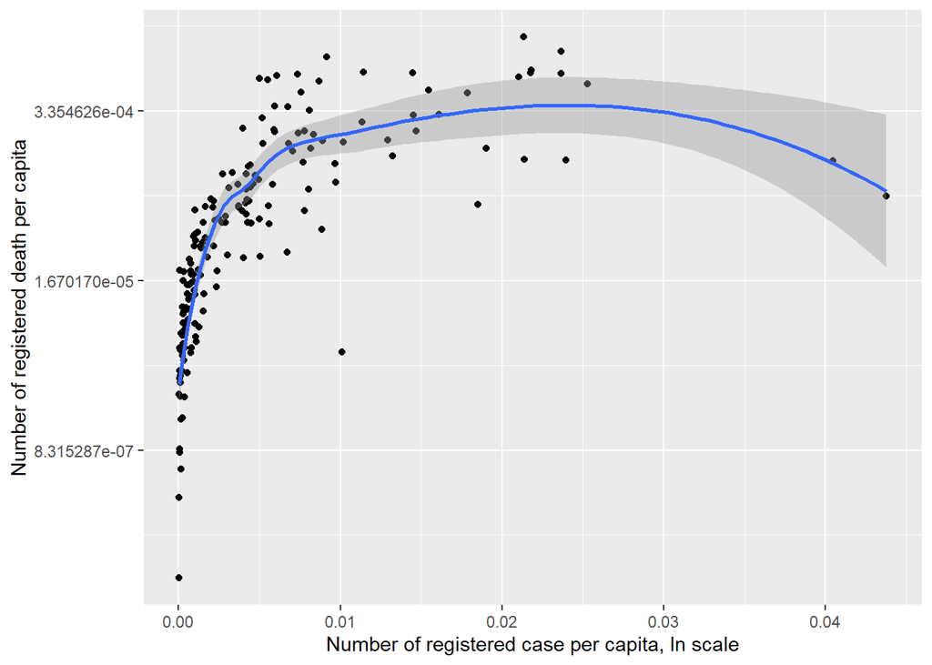

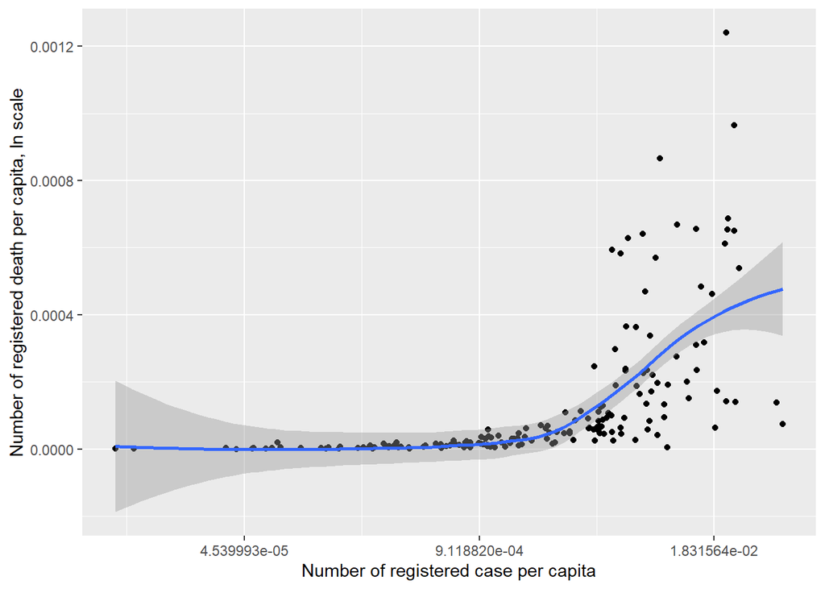

```
##
## Call:
## lm(formula = ln_death_per_capita ~ ln_case_per_capita, data = df)
##
## Coefficients:
##        (Intercept)  ln_case_per_capita
##            -4.2882              0.9411
```

```
##
## Call:
## lm(formula = ln_death_per_capita ~ ln_case_per_capita, data = df)
##
## Residuals:
##     Min      1Q  Median      3Q     Max
## -3.6481 -0.3962  0.0791  0.4922  2.4833
##
## Coefficients:
##                    Estimate Std. Error t value Pr(>|t|)
## (Intercept)        -4.28825    0.24669  -17.38   <2e-16 ***
## ln_case_per_capita  0.94114    0.03795   24.80   <2e-16 ***
## ---
## Signif. codes:  0 '***' 0.001 '**' 0.01 '*' 0.05 '.' 0.1 ' ' 1
##
## Residual standard error: 0.8465 on 168 degrees of freedom
## Multiple R-squared:  0.7855, Adjusted R-squared:  0.7842
## F-statistic: 615.1 on 1 and 168 DF,  p-value: < 2.2e-16
```

```
##
## Call:
## lm_robust(formula = ln_death_per_capita ~ ln_case_per_capita,
##     data = df, se_type = "HC2")
##
## Standard error type:  HC2
##
## Coefficients:
##                    Estimate Std. Error t value  Pr(>|t|) CI Lower CI Upper  DF
## (Intercept)         -4.2882    0.29961  -14.31 6.811e-31   -4.880   -3.697 168
## ln_case_per_capita   0.9411    0.04566   20.61 7.142e-48    0.851    1.031 168
##
## Multiple R-squared:  0.7855 ,    Adjusted R-squared:  0.7842
## F-statistic: 424.9 on 1 and 168 DF,  p-value: < 2.2e-16
```

```
##
## Call:
## lm_robust(formula = ln_death_per_capita ~ ln_case_per_capita +
##     ln_case_per_capita_sq, data = df)
##
## Standard error type:  HC2
##
## Coefficients:
##                       Estimate Std. Error t value  Pr(>|t|) CI Lower CI Upper
## (Intercept)           -4.06315    0.96580 -4.2070 4.214e-05 -5.96990 -2.15640
## ln_case_per_capita     1.01221    0.28173  3.5928 4.301e-04  0.45599  1.56843
## ln_case_per_capita_sq  0.00522    0.02009  0.2598 7.953e-01 -0.03445  0.04489
##                        DF
## (Intercept)           167
## ln_case_per_capita    167
## ln_case_per_capita_sq 167
##
## Multiple R-squared:  0.7856 ,    Adjusted R-squared:  0.783
## F-statistic: 210.2 on 2 and 167 DF,  p-value: < 2.2e-16
```

```
##
## Call:
## lm_robust(formula = ln_death_per_capita ~ ln_case_per_capita +
##     ln_case_per_capita_sq + ln_case_per_capita_cb, data = df)
##
## Standard error type:  HC2
##
## Coefficients:
##                       Estimate Std. Error t value Pr(>|t|)  CI Lower  CI Upper
## (Intercept)            -8.2243    3.01617 -2.7268 0.007083 -14.17933 -2.269348
## ln_case_per_capita     -0.9500    1.32032 -0.7195 0.472820  -3.55680  1.656760
## ln_case_per_capita_sq  -0.2856    0.18368 -1.5550 0.121841  -0.64827  0.077018
## ln_case_per_capita_cb  -0.0136    0.00813 -1.6725 0.096304  -0.02965  0.002454
##                        DF
## (Intercept)           166
## ln_case_per_capita    166
## ln_case_per_capita_sq 166
## ln_case_per_capita_cb 166
##
## Multiple R-squared:   0.79 , Adjusted R-squared:  0.7862
## F-statistic: 145.5 on 3 and 166 DF,  p-value: < 2.2e-16
```

```
##
## Call:
## lm_robust(formula = ln_death_per_capita ~ lspline(ln_case_per_capita,
##     cutoff_ln_1, cutoff_ln_2), data = df)
##
## Standard error type:  HC2
##
## Coefficients:
##                                                        Estimate Std. Error
## (Intercept)                                             -5.2564     0.9736
## lspline(ln_case_per_capita, cutoff_ln_1, cutoff_ln_2)1   0.8278     0.1213
## lspline(ln_case_per_capita, cutoff_ln_1, cutoff_ln_2)2   0.1618     0.1555
##                                                        t value  Pr(>|t|)
## (Intercept)                                             -5.399 2.272e-07
## lspline(ln_case_per_capita, cutoff_ln_1, cutoff_ln_2)1   6.822 1.573e-10
## lspline(ln_case_per_capita, cutoff_ln_1, cutoff_ln_2)2   1.040 2.996e-01
##                                                        CI Lower CI Upper  DF
## (Intercept)                                             -7.1786  -3.3342 167
## lspline(ln_case_per_capita, cutoff_ln_1, cutoff_ln_2)1   0.5883   1.0674 167
## lspline(ln_case_per_capita, cutoff_ln_1, cutoff_ln_2)2  -0.1452   0.4688 167
##
## Multiple R-squared:  0.787 , Adjusted R-squared:  0.7845
## F-statistic: 212.6 on 2 and 167 DF,  p-value: < 2.2e-16
```

```
##
## Call:
## lm_robust(formula = ln_death_per_capita ~ ln_case_per_capita,
##     data = df, weights = population)
##
## Weighted, Standard error type:  HC2
##
## Coefficients:
##                    Estimate Std. Error t value  Pr(>|t|) CI Lower CI Upper  DF
## (Intercept)         -4.2511     0.5224  -8.137 8.630e-14  -5.2825    -3.22 168
## ln_case_per_capita   0.9062     0.0829  10.932 2.377e-21   0.7426     1.07 168
##
## Multiple R-squared:  0.8939 ,    Adjusted R-squared:  0.8933
## F-statistic: 119.5 on 1 and 168 DF,  p-value: < 2.2e-16
```